# Economic Causality

Carlvin M

2/06/2022

## Data Description:

- Data tenure: 1955 - 1997
- Information about 18 Spanish regions is available
  - One of which is an average for the whole country of Spain (we’ll remove that)
- The treatment year is considered to be year 1975
- The treatment region is “Basque Country (Pais Vasco)”
- The economic impact measurement variable is GDP per capita (in thousands)

```r
data(basque)
head(basque,10)
```

```
##    regionno     regionname year   gdpcap sec.agriculture sec.energy
## 1         1 Spain (Espana) 1955 2.354542              NA         NA
## 2         1 Spain (Espana) 1956 2.480149              NA         NA
## 3         1 Spain (Espana) 1957 2.603613              NA         NA
## 4         1 Spain (Espana) 1958 2.637104              NA         NA
## 5         1 Spain (Espana) 1959 2.669880              NA         NA
## 6         1 Spain (Espana) 1960 2.869966              NA         NA
## 7         1 Spain (Espana) 1961 3.047486           19.54       4.71
## 8         1 Spain (Espana) 1962 3.273279              NA         NA
## 9         1 Spain (Espana) 1963 3.493502           19.05       4.31
## 10        1 Spain (Espana) 1964 3.600114              NA         NA
##    sec.industry sec.construction sec.services.venta sec.services.nonventa
## 1            NA               NA                 NA                    NA
## 2            NA               NA                 NA                    NA
## 3            NA               NA                 NA                    NA
```

[output cut: 29 more lines]

```r
colnames(basque)
```

```
##  [1] "regionno"              "regionname"            "year"
##  [4] "gdpcap"                "sec.agriculture"       "sec.energy"
##  [7] "sec.industry"          "sec.construction"      "sec.services.venta"
## [10] "sec.services.nonventa" "school.illit"          "school.prim"
## [13] "school.med"            "school.high"           "school.post.high"
## [16] "popdens"               "invest"
```

```r
unused <- c("sec.agriculture", "sec.energy" , "sec.industry" , "sec.construction" ,
           "sec.services.venta" , "sec.services.nonventa", "school.illit", "school.prim",
           "school.med", "school.high", "school.post.high", "popdens")
basq_clean <- basque[,!(names(basque) %in% unused)]
basq_clean <- basq_clean %>%
  mutate(post = ifelse(year > 1975, 1, 0),
         treat = ifelse(regionname == "Basque Country (Pais Vasco)", 1, 0),
         regionname = as.factor(regionname)) %>%
  filter(regionno != 1)

head(basq_clean)
```

```
##    regionno regionname year   gdpcap invest post treat
## 44        2  Andalucia 1955 1.688732     NA    0     0
## 45        2  Andalucia 1956 1.758498     NA    0     0
## 46        2  Andalucia 1957 1.827621     NA    0     0
## 47        2  Andalucia 1958 1.852756     NA    0     0
## 48        2  Andalucia 1959 1.878035     NA    0     0
## 49        2  Andalucia 1960 2.010140     NA    0     0
```

## First Difference Estimate

Before going into Difference in Differences method, let’s look at First Differences and what it does. Our goal here is to quantify the impact of GDP before and after the terrorist conflict in Basque country.

The general trend of GDP per capita for the Basque country:

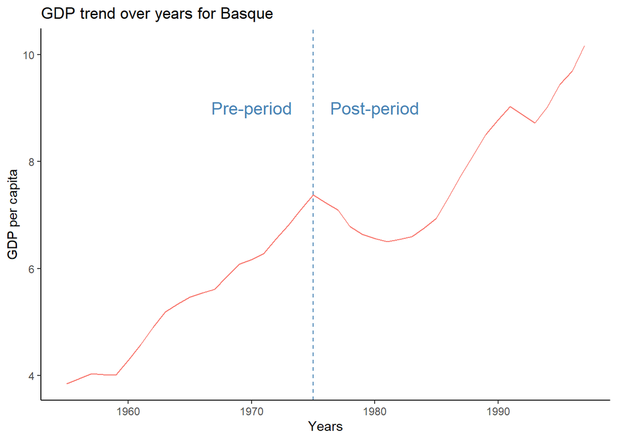

```r
# Calculating first differences
basq_fdid <- basq_clean %>%
  filter(treat == 1)
ggplot(basq_fdid, aes(x=year, y=gdpcap)) +
  geom_line(color = "#F8766D") + theme_classic() +
  geom_vline(xintercept=1975, color = "steelblue", linetype = "dashed") +
  labs(title="GDP trend over years for Basque",
       y="GDP per capita",x="Years", color = "Region") +
  annotate("text", x = 1970, y = 9, label = "Pre-period", size  =5, color = "steelblue") +
  annotate("text", x = 1980, y = 9, label = "Post-period", size  =5, color = "steelblue")
```

Our goal is to capture the magnitude of plunge that we see. The first difference estimate will tell us the difference in GDP before and after the treatment. We can derive our first difference equation by having GDP as the dependent variable and pre-post indicator as the independent variable.

```r
# Calculating first differences
f_did <- lm(data = basq_fdid, gdpcap ~ post)
stargazer(f_did, type="text")
```

```
##
## ===============================================
##                         Dependent variable:
##                     ---------------------------
##                               gdpcap
## -----------------------------------------------
## post                         2.484***
##                               (0.352)
##
## Constant                     5.382***
##                               (0.252)
##
## -----------------------------------------------
## Observations                    43
## R2                             0.549
## Adjusted R2                    0.538
## Residual Std. Error       1.153 (df = 41)
## F Statistic           49.921*** (df = 1; 41)
## ===============================================
## Note:               *p<0.1; **p<0.05; ***p<0.01
```

The coefficient of post indicator suggests that there is an increase of GDP per capita by ~2.5 units. That’s because there’s an expected problem as we mentioned earlier. The trend in GDP could have been altered because of a lot of other variables, besides the terrorist conflict, occurring at the same time -confounders. Possible confounders in this case are:

- Passing of a trade law which would affect local businesses and GDP
- Mutiny within local groups
- Perception of corrupt or dysfunctional government

The solution to this is to compare the trend to a control region which was not impacted by terrorist conflict. This comparison allows us to remove the confounding effect after the intervention period and arrive at the real causal impact. That’s where Difference in differences come in.

## Difference in differences (DiD):

*Assumption:* The treatment group and control group must follow the same trend in the pre-period.

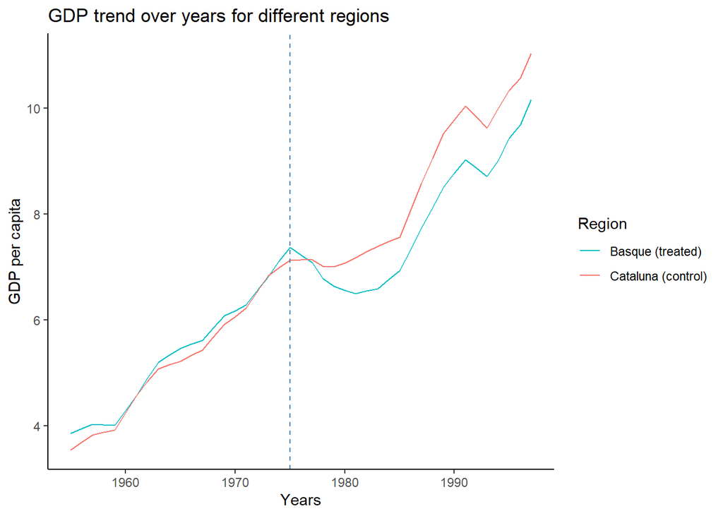

```r
# For this analysis, the control region was identified by spotting for the region that had the lowest variation in % difference of GDP across years between each region and Basque country.
# Alternatively, we can look for the control region by eyeballing the GDP trend for treatment and control groups when feasible. In this case, Cataluna region was recognized to be the best control region. Let's look at the GDP trend for test and control regions below:

#Picking the closest control group based on gdp
pre <- basq_clean %>%
  filter(post == 0) %>%
  left_join(dplyr::select(basq_clean[basq_clean$post==0 & basq_clean$treat == 1, ], gdpcap, year),
            by = c("year"= 'year')) %>%
  mutate(perc_diff = (gdpcap.y - gdpcap.x) / gdpcap.y) %>%
  group_by(regionname) %>%
  summarise(gdp_var = abs(var(perc_diff))) %>%
  arrange(gdp_var)
# Validating assumption
did_data <- basq_clean %>%
  filter(regionname %in% c("Basque Country (Pais Vasco)", "Cataluna"))
ggplot(did_data, aes(x=year, y=gdpcap, group = regionname)) +
  geom_line(aes(color = regionname)) +
  theme_classic() +
  geom_vline(xintercept=1975, color = "steelblue", linetype = "dashed") +
  labs(title="GDP trend over years for different regions",
       y="GDP per capita",x="Years", color = "Region") +
  scale_color_manual(labels = c("Basque (treated)", "Cataluna (control)"), values = c("#00BFC4", "#F8766D"))
```

GDP trend for Cataluna region goes hand in hand with Basque’s GDP with an exception for a few years in the pre-period. Thus, there should be no problem in considering Cataluna to be our control region.

We then fit the regression with GDP as the dependent variable and treatment indicator and pre-post indicator as the independent variables. The key aspect here is to feed the interaction between treatment and pre-post indicator as we want the estimate to contain the effect of being treated along with being in post-period in comparison to not being treated and being in pre-period.

After fitting, let’s look at the regression results below:

```r
# Difference in differences
did <- lm(data = did_data, gdpcap ~ treat*post)
stargazer(did, type="text")
```

```
##
## ===============================================
##                         Dependent variable:
##                     ---------------------------
##                               gdpcap
## -----------------------------------------------
## treat                          0.139
##                               (0.376)
##
## post                         3.339***
##                               (0.371)
##
## treat:post                    -0.855
##                               (0.525)
##
## Constant                     5.244***
##                               (0.266)
##
## -----------------------------------------------
## Observations                    86
## R2                             0.607
## Adjusted R2                    0.593
## Residual Std. Error       1.218 (df = 82)
## F Statistic           42.279*** (df = 3; 82)
## ===============================================
## Note:               *p<0.1; **p<0.05; ***p<0.01
```

Looking at the estimate of the interaction variable, the model suggests that the GDP in Basque country reduced by 0.855 units because of the terrorist intervention that happened.

There is a big difference between estimates provided by First difference method and the DD method. Quantitatively, we can see how the First difference estimates could be deceiving to look at.

Verify that pre-treatment trends are parallel for a reasonable timeframe Cross validate results using alternative control or treatment groups Test if there exists a treatment reversal effect

## ——————————————————————————————-

## Causal Impact

The motivation to use Causal Impact methodology is that the Difference in differences in limited in the following ways:

- DiD is traditionally based on a static regression model that assumes independent and identically distributed data despite the fact that the design has a temporal component
- Most DiD analyses only consider two time points: before and after the intervention. In practice, we also have to consider the manner in which an effect evolves over time, especially its onset and decay structure

The idea here is to use the trend in the control group to forecast the trend in the treated group which would be the trend if the treatment had not happened. Then the actual causal estimate would be the **difference in the actual trend vs the counter-factual trend of the treated group that we predicted**.

Essentially, Causal Impact methodology is very close to the Synthetic control methodology.

Control region in this case is considered to be Cataluna again. With the treated and control region’s GDP in place, let’s feed them to the Causal Impact function in R and look at the results.

```
## Posterior inference {CausalImpact}
##
##                          Average         Cumulative
## Actual                   7.9             173.1
## Prediction (s.d.)        8.6 (0.32)      190.3 (6.99)
## 95% CI                   [8, 9.3]        [176, 203.7]
##
## Absolute effect (s.d.)   -0.78 (0.32)    -17.22 (6.99)
## 95% CI                   [-1.4, -0.14]   [-30.7, -2.98]
##
## Relative effect (s.d.)   -9% (3.7%)      -9% (3.7%)
## 95% CI                   [-16%, -1.6%]   [-16%, -1.6%]
##
## Posterior tail-area probability p:   0.00501
## Posterior prob. of a causal effect:  99.499%
##
## For more details, type: summary(impact, "report")
```

[output not shown]

## ——————————————————————————————-

## Synthetic Control:

Both the methods use the help of control groups to construct a counter-factual of the treated group giving us as idea of what the trend is if the treatment had not happened. The counter-factual GDP of the treated group would be predicted by the GDP of the control groups and also other possible covariates in the control group.

The **synth algorithm** predicts the counter-factual by **assigning weights to the regressors in the control groups** which is helpful in identifying individual regressors and their influence in prediction. Ultimately, the true causal impact is the **difference in GDP between actual GDP and the counter-factual GDP if the treatment had not happened**.

**Synthetic Control uses only pre-treatment variables** for matching while **Causal Impact uses the full pre and post-treatment time series of predictor variables** for matching.

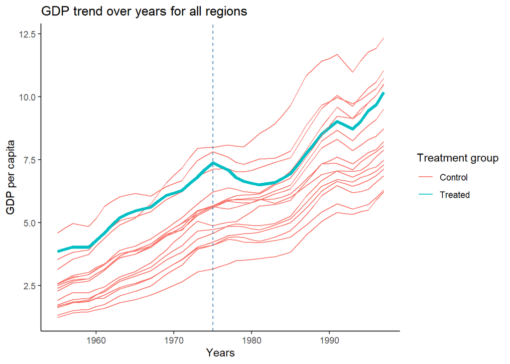

As seen from the plot above, all the control regions have a similar upward trend in GDP as Basque country’s in the pre-period. This suggests that GDP in Basque could be constructed fairly accurately using the data from other regions.

```
##
## X1, X0, Z1, Z0 all come directly from dataprep object.
##
##
## ****************
##  searching for synthetic control unit
##
##
## ****************
## ****************
## ****************
##
## MSPE (LOSS V): 0.008864606
##
## solution.v:
##  0.02773094 1.194e-07 1.60609e-05 0.0007163836 1.486e-07 0.002423908 0.0587055 0.2651997 0.02851006 0.291276 0.007994382 0.004053188 0.009398579 0.303975
##
## solution.w:
##  2.53e-08 4.63e-08 6.44e-08 2.81e-08 3.37e-08 4.844e-07 4.2e-08 4.69e-08 0.8508145 9.75e-08 3.2e-08 5.54e-08 0.1491843 4.86e-08 9.89e-08 1.162e-07
```

After execution, Let’s look at the plot between actual GDP and the counter-factual GDP.

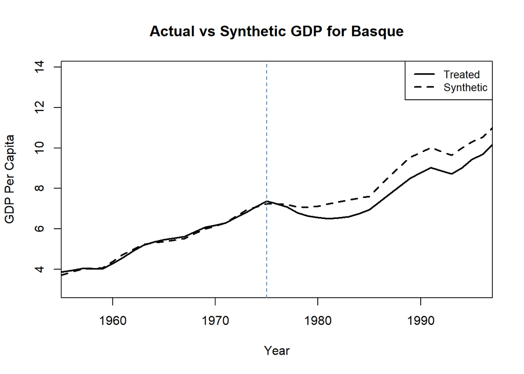

The path-graph shows how the smooth relationship is between the synthetic and actual trend in the pre-period and how it deviates gradually once the treatment happens. That difference in trends in the post-period would be our average treatment effect.

The root mean squared error of the Actual and Synthetic trends can be seen to be **0.57 units**.

```r
# Calculating root mean squared error between actual and synthetic
round(sqrt(mean((dataprep.out$Y1plot - (dataprep.out$Y0plot %*% synth.out$solution.w))^2)), 2)
```

```
## [1] 0.57
```

We can conclude that the true causal impact of terrorist conflict on Basque country is reduction of GDP by 0.57 units calculated using Synthetic control method.

Comparing results from all 3 methods:

[output not shown]

The magnitude of the causal impact differs only by a small margin between the three methods and there is no method which will give us the “correct answer”. Most times, the approaches we use will be restricted by the nature of the experiment and what causal threats we are trying to address.